# MSDS Capstone

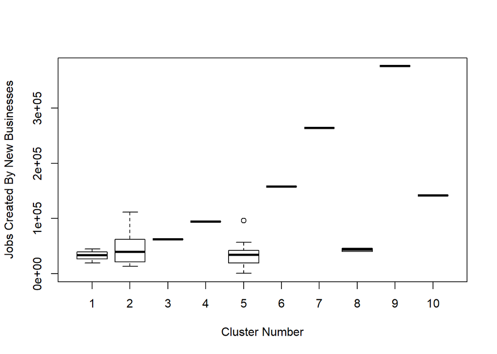

```r
boxplot(job_creation_births ~ memEucCom, data = xsubset, xlab = "Cluster Number", ylab = "Jobs Created By New Businesses")
```

Doing a better job of spreading out the points but spreading them out way too much. 10 clusters are identified, with the majority of points in three groups.

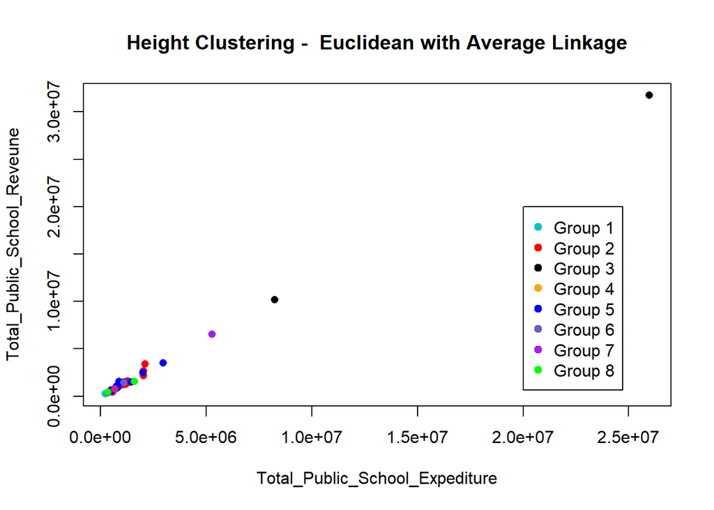

```r
#Total_Public_School_Expediture and Total_Public_School_Reveune
plot(clean_city$Total_Public_School_Expediture, clean_city$Total_Public_School_Reveune, pch=16, main="Height Clustering -  Euclidean with Average Linkage", ylab = "Total_Public_School_Reveune", xlab = "Total_Public_School_Expediture")
for (i in 1:9)  points(clean_city$Total_Public_School_Expediture[memEucCom == i],clean_city$Total_Public_School_Reveune[memEucCom == i],pch=16,col=colused[i])
legend(20000000, 20000000, legend=c("Group 1", "Group 2", "Group 3", "Group 4", "Group 5", "Group 6", "Group 7", "Group 8"), col=c("turquoise3", "red", "black", "orange","blue", "slateblue",  "purple","green", "violetred"), pch = 19)
```

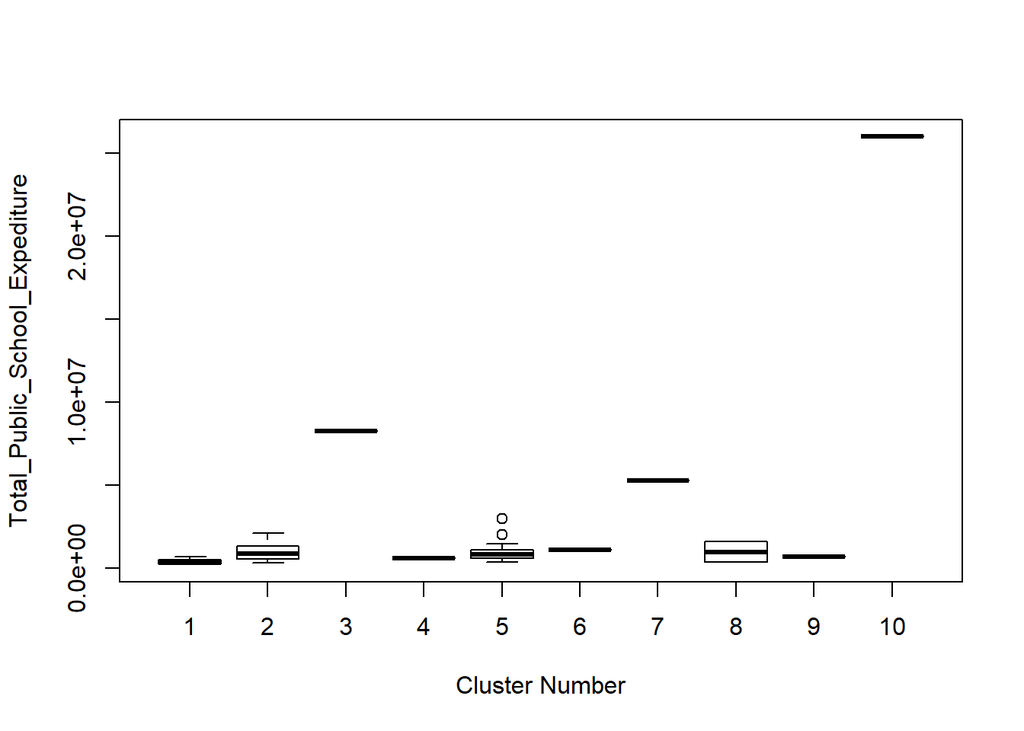

```r
boxplot(Total_Public_School_Expediture ~ memEucCom, data = xsubset, xlab = "Cluster Number", ylab = "Total_Public_School_Expediture")
```

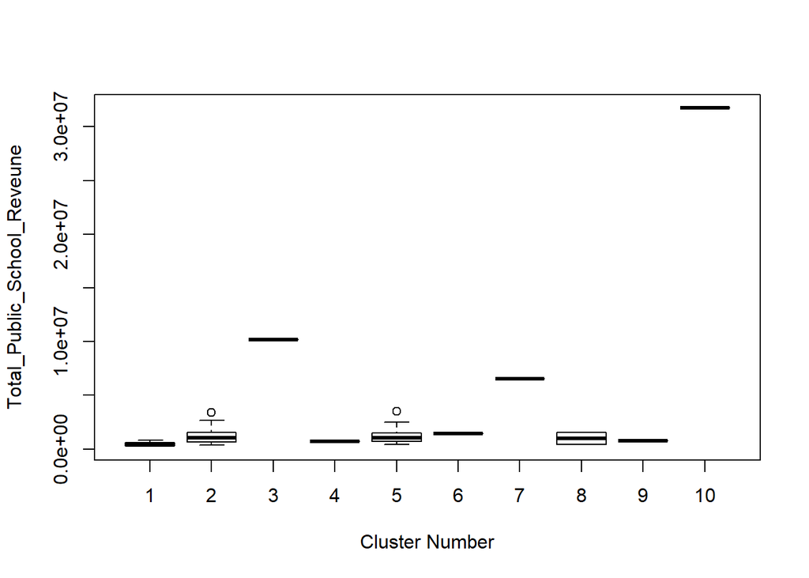

```r
boxplot(Total_Public_School_Reveune ~ memEucCom, data = xsubset, xlab = "Cluster Number", ylab = "Total_Public_School_Reveune")
```

####Manhattan with Complete Linkage

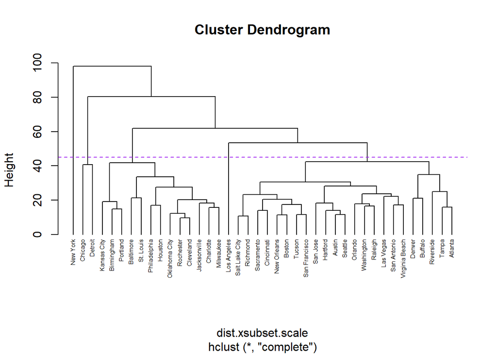

```r
#chosing only variables identified by PCA and not any identifiers or labels
xsubset = clean_city[,c(3, 4, 9, 11, 12, 13, 14, 16, 17, 20, 23, 25, 27, 28, 29, 32, 33, 34, 38, 47, 49, 50, 51, 55, 60, 61, 62, 66, 69, 70, 71, 72, 73, 74, 75, 76, 77)]
xsubset.scale = scale(xsubset)

############ fitting hierarchical models - Single  ############
dist.xsubset.scale = dist(xsubset.scale, method="manhattan")
hc.complete = hclust(dist.xsubset.scale,method="complete") #furthest distance btwn cluster

#Plot Dendrogram
par(mfrow=c(1,1))
plot(hc.complete,cex=0.5, labels = clean_city$`ï..City`, hang = -1)
abline(h=c(45),col=c("purple","red","blue"),lty=2)  # drawing line where the biggest two clusters separate
```

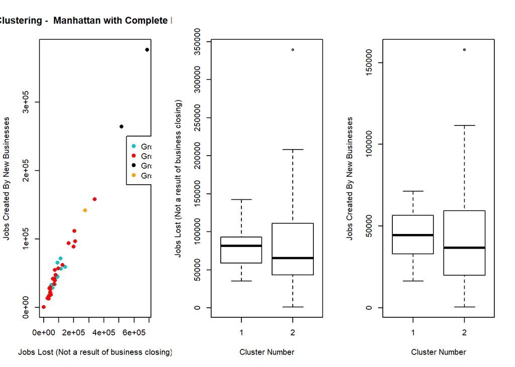

```r
#plotting clusters
colused = c("turquoise3", "red", "black", "orange","blue", "slateblue",  "purple","green", "violetred" )
nclust= 4#change this number for the number of clusters (need 4 because of that first two outlier clusters)
memEucCom = cutree(hc.complete, k=nclust)#cuts the dendrogram
par(mfrow=c(1,3))
#job_destruction_continuers and job_creation_births
plot(clean_city$job_destruction_continuers, clean_city$job_creation_births ,pch=16,main=paste(nclust," Clustering -  Manhattan with Complete Linkage"), ylab = "Jobs Created By New Businesses", xlab = "Jobs Lost (Not a result of business closing)")
for (i in 1:10)  points(clean_city$job_destruction_continuers[memEucCom == i],clean_city$job_creation_births[memEucCom == i],pch=16,col=colused[i])
legend(550000, 250000, legend=c("Group 1", "Group 2", "Group 3", "Group 4"), col=c("turquoise3", "red", "black", "orange"), pch = 19)
boxplot(job_destruction_continuers[memEucCom<3] ~ memEucCom[memEucCom<3], data = xsubset, xlab = "Cluster Number", ylab = "Jobs Lost (Not a result of business closing)")
boxplot(job_creation_births[memEucCom<3] ~ memEucCom[memEucCom<3], data = xsubset, xlab = "Cluster Number", ylab = "Jobs Created By New Businesses")
```

```r
median(xsubset$job_destruction_continuers[memEucCom=1])
```

```
## [1] 74877
```

```r
median(xsubset$job_destruction_continuers[memEucCom=2])
```

```
## [1] 47221
```

```r
median(xsubset$job_creation_births[memEucCom=1])
```

```
## [1] 33593
```

```r
median(xsubset$job_creation_births[memEucCom=2])
```

```
## [1] 20352
```

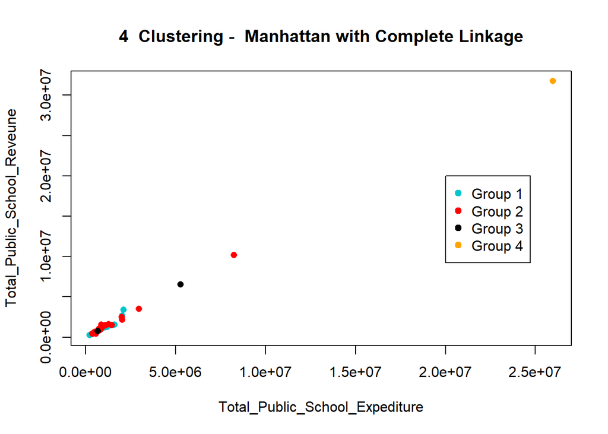

```r
#Total_Public_School_Expediture and Total_Public_School_Reveune
plot(clean_city$Total_Public_School_Expediture, clean_city$Total_Public_School_Reveune, pch=16, main=paste(nclust," Clustering -  Manhattan with Complete Linkage"), ylab = "Total_Public_School_Reveune", xlab = "Total_Public_School_Expediture")
for (i in 1:9)  points(clean_city$Total_Public_School_Expediture[memEucCom == i],clean_city$Total_Public_School_Reveune[memEucCom == i],pch=16,col=colused[i])
legend(20000000, 20000000, legend=c("Group 1", "Group 2", "Group 3", "Group 4"), col=c("turquoise3", "red", "black", "orange"), pch = 19)
```

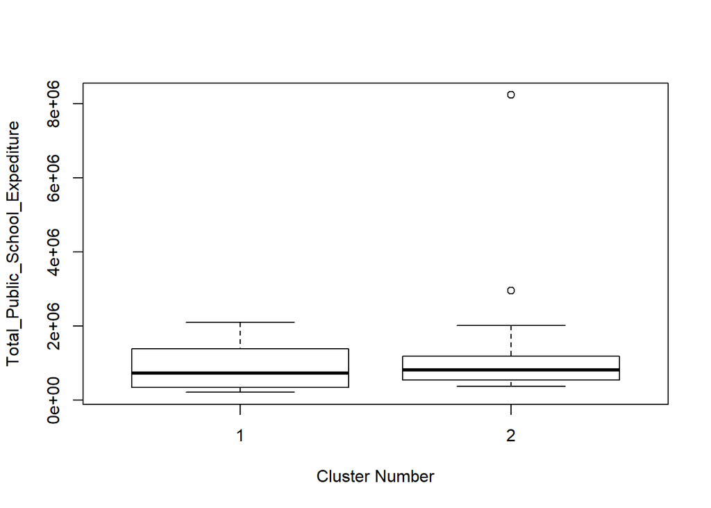

```r
boxplot(Total_Public_School_Expediture[memEucCom<3] ~ memEucCom[memEucCom<3], data = xsubset, xlab = "Cluster Number", ylab = "Total_Public_School_Expediture")
```

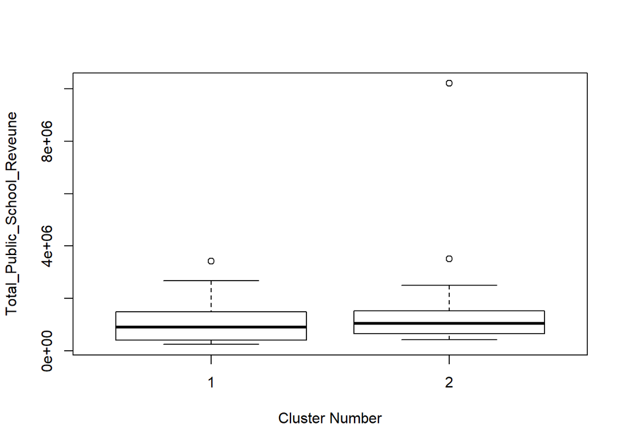

```r
boxplot(Total_Public_School_Reveune[memEucCom<3] ~ memEucCom[memEucCom<3], data = xsubset, xlab = "Cluster Number", ylab = "Total_Public_School_Reveune")
```

```r
median(xsubset$Total_Public_School_Expediture[memEucCom==1])
```

```
## [1] 721814
```

```r
median(xsubset$Total_Public_School_Expediture[memEucCom==2])
```

```
## [1] 810004
```

```r
median(xsubset$Total_Public_School_Reveune[memEucCom==1])
```

```
## [1] 906750
```

```r
median(xsubset$Total_Public_School_Reveune[memEucCom==2])
```

```
## [1] 1039960
```

Again, clusters 1 and 2 medians look great.

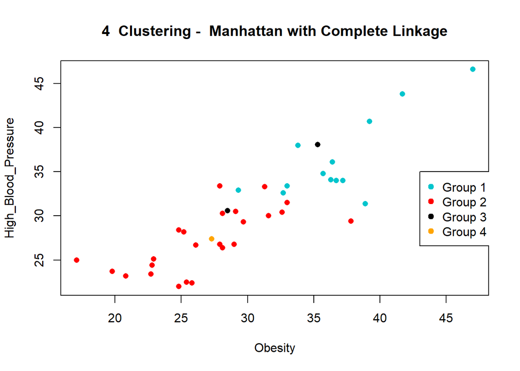

```r
#Obesity and High Blood Pressure
plot(clean_city$Obesity, clean_city$High_Blood_Pressure, pch=16, main=paste(nclust," Clustering -  Manhattan with Complete Linkage"), ylab = "High_Blood_Pressure", xlab = "Obesity")
for (i in 1:9)  points(clean_city$Obesity[memEucCom == i],clean_city$High_Blood_Pressure[memEucCom == i],pch=16,col=colused[i])
legend(43, 35, legend=c("Group 1", "Group 2", "Group 3", "Group 4"), col=c("turquoise3", "red", "black", "orange"), pch = 19)
```

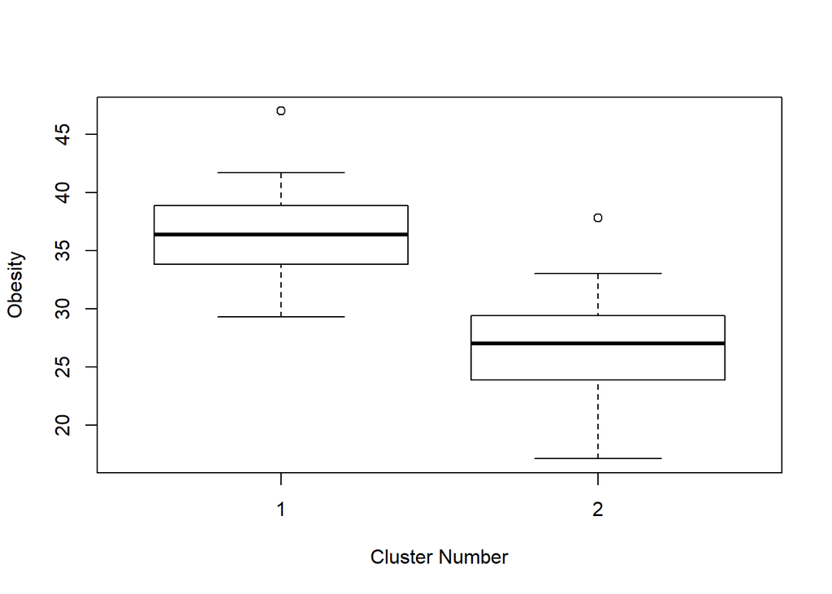

```r
boxplot(Obesity[memEucCom<3] ~ memEucCom[memEucCom<3], data = xsubset, xlab = "Cluster Number", ylab = "Obesity")
```

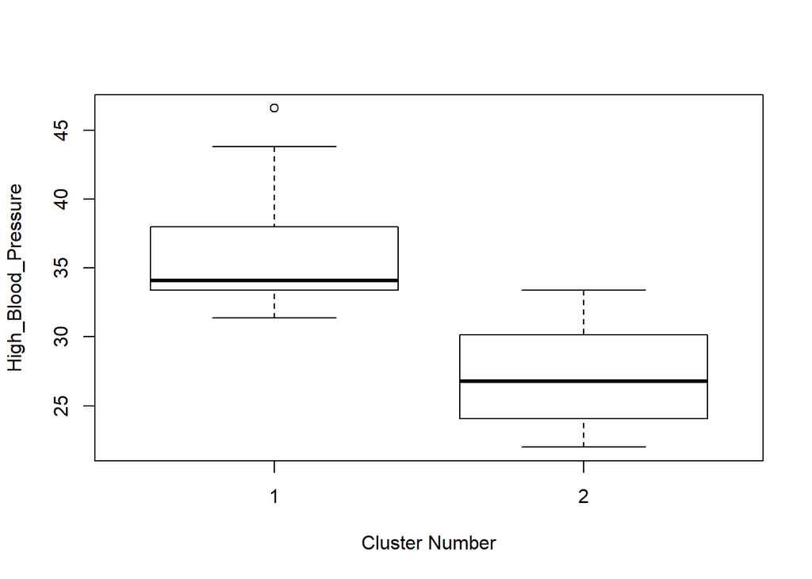

```r
boxplot(High_Blood_Pressure[memEucCom<3] ~ memEucCom[memEucCom<3], data = xsubset, xlab = "Cluster Number", ylab = "High_Blood_Pressure")
```

```r
median(xsubset$Obesity[memEucCom==1])
```

```
## [1] 36.4
```

```r
median(xsubset$Obesity[memEucCom==2])
```

```
## [1] 27
```

```r
median(xsubset$High_Blood_Pressure[memEucCom==1])
```

```
## [1] 34.1
```

```r
median(xsubset$High_Blood_Pressure[memEucCom==2])
```

```
## [1] 26.8
```

On point

Truth Table from Manhattan Complete - I: Cluster 2 (total of 24 data points) Had 17 I’s and 7 S’s S: Cluster 1 (total of 13 points) Had 10 S’s and three I’s

Cluster 2 is basically I’s Cluster 1 is basically S’s without the outliers of the big cities

####Manhattan with Average Linkage Same issue as Eucledean Average - either all one group or multiple tiny groups

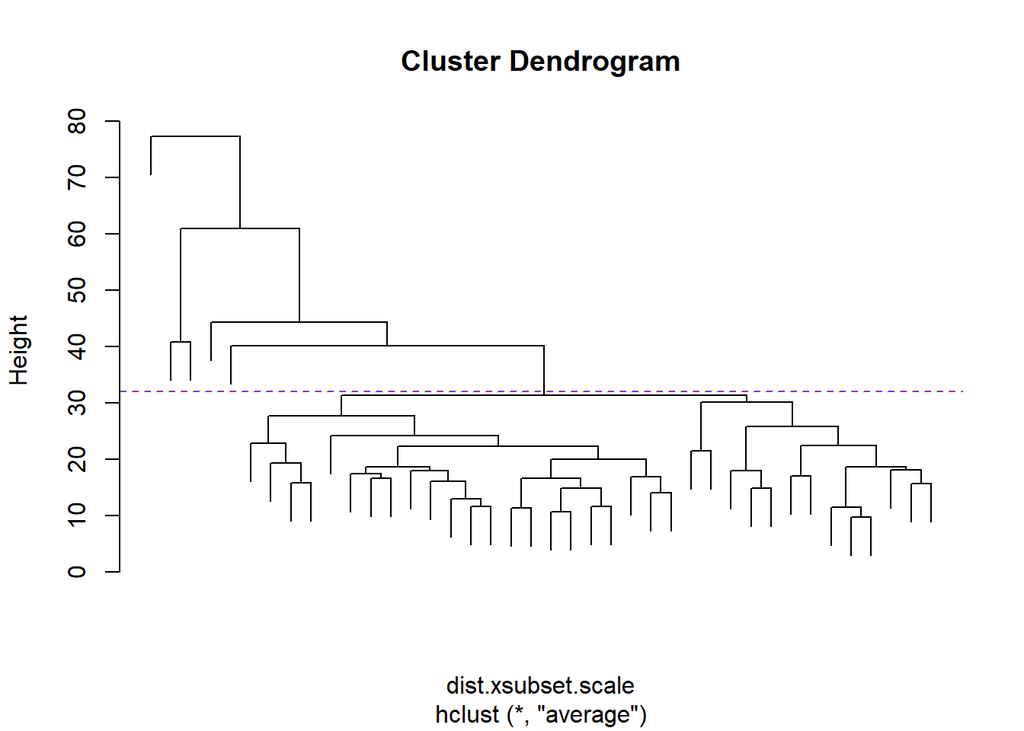

```r
#chosing only variables identified by PCA and not any identifiers or labels
xsubset = clean_city[,c(3, 4, 9, 11, 12, 13, 14, 16, 17, 20, 23, 25, 27, 28, 29, 32, 33, 34, 38, 47, 49, 50, 51, 55, 60, 61, 62, 66, 69, 70, 71, 72, 73, 74, 75, 76, 77)]
xsubset.scale = scale(xsubset)

############ fitting hierarchical models - Single  ############
dist.xsubset.scale = dist(xsubset.scale, method="manhattan")
hc.complete = hclust(dist.xsubset.scale,method="average") #furthest distance btwn cluster

#Plot Dendrogram
par(mfrow=c(1,1))
plot(hc.complete,cex=0.5,labels=F)
abline(h=c(32),col=c("purple","red","blue"),lty=2)  # drawing line where the biggest two clusters separate
```

All one GRoup

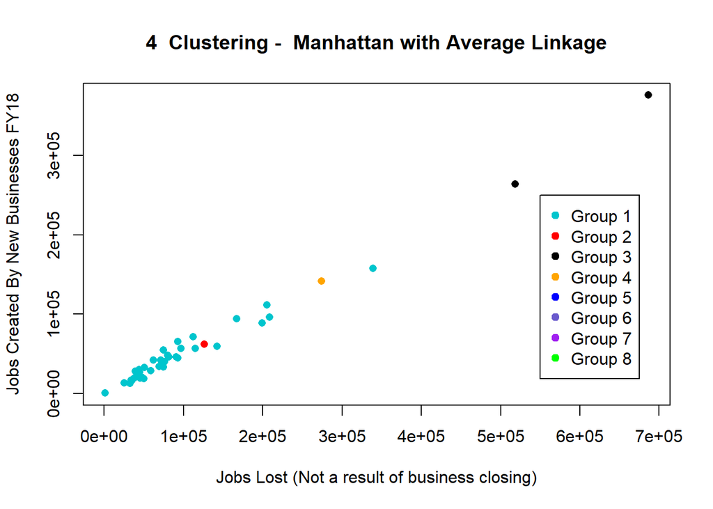

```r
#plotting clusters
colused = c("turquoise3", "red", "black", "orange","blue", "slateblue",  "purple","green", "violetred" )
nclust= 4#change this number for the number of clusters (need 4 because of that first two outlier clusters)
memEucCom = cutree(hc.complete, k=nclust)#cuts the dendrogram

#job_destruction_continuers and job_creation_births
plot(clean_city$job_destruction_continuers, clean_city$job_creation_births ,pch=16,main=paste(nclust," Clustering -  Manhattan with Average Linkage"), ylab = "Jobs Created By New Businesses FY18", xlab = "Jobs Lost (Not a result of business closing)")
for (i in 1:10)  points(clean_city$job_destruction_continuers[memEucCom == i],clean_city$job_creation_births[memEucCom == i],pch=16,col=colused[i])
legend(550000, 250000, legend=c("Group 1", "Group 2", "Group 3", "Group 4", "Group 5", "Group 6", "Group 7", "Group 8"), col=c("turquoise3", "red", "black", "orange","blue", "slateblue",  "purple","green", "violetred"), pch = 19)
```

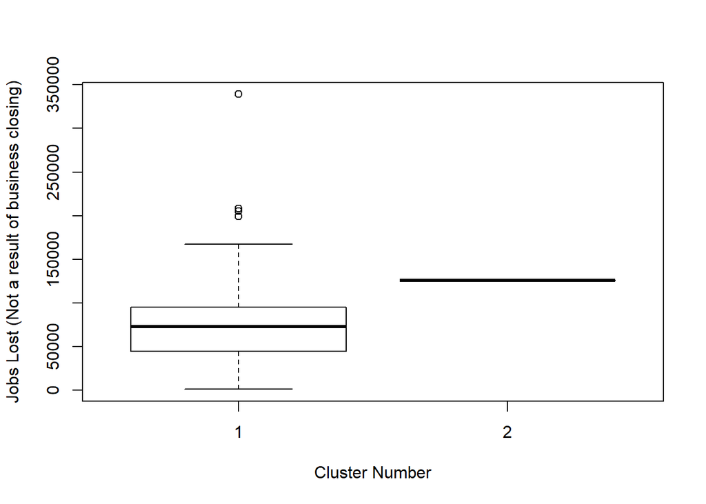

```r
boxplot(job_destruction_continuers[memEucCom<3] ~ memEucCom[memEucCom<3], data = xsubset, xlab = "Cluster Number", ylab = "Jobs Lost (Not a result of business closing)")
```

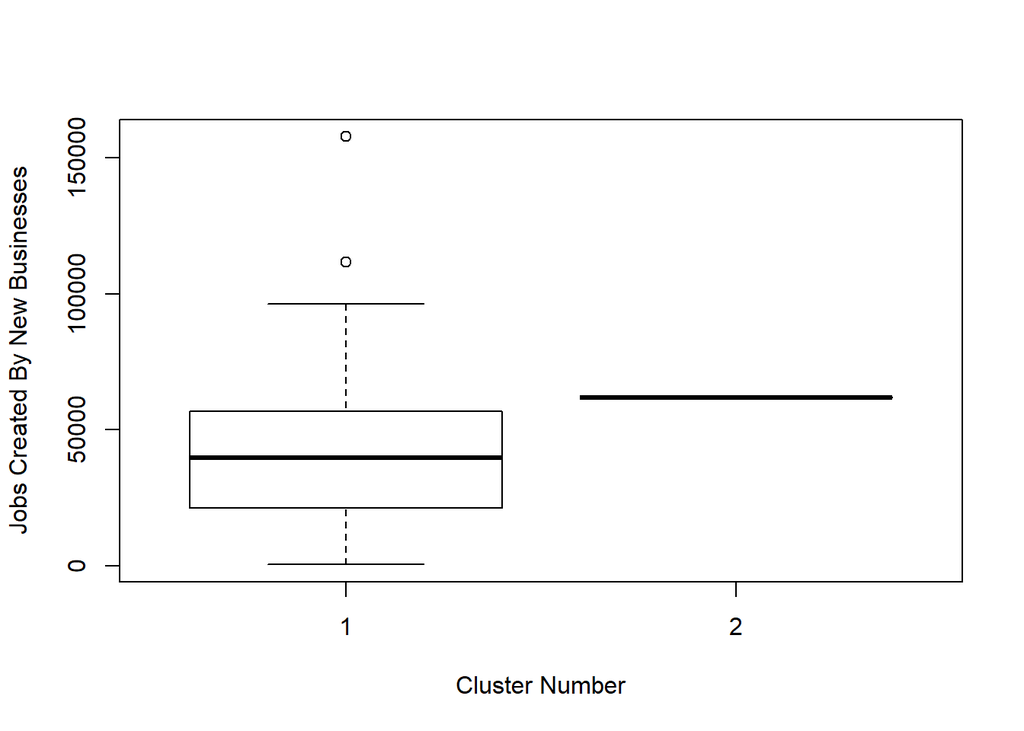

```r
boxplot(job_creation_births[memEucCom<3] ~ memEucCom[memEucCom<3], data = xsubset, xlab = "Cluster Number", ylab = "Jobs Created By New Businesses")
```

```r
median(xsubset$job_destruction_continuers[memEucCom=1])
```

```
## [1] 74877
```

```r
median(xsubset$job_destruction_continuers[memEucCom=2])
```

```
## [1] 47221
```

```r
median(xsubset$job_creation_births[memEucCom=1])
```

```
## [1] 33593
```

```r
median(xsubset$job_creation_births[memEucCom=2])
```

```
## [1] 20352
```

Bunch of tiny groups

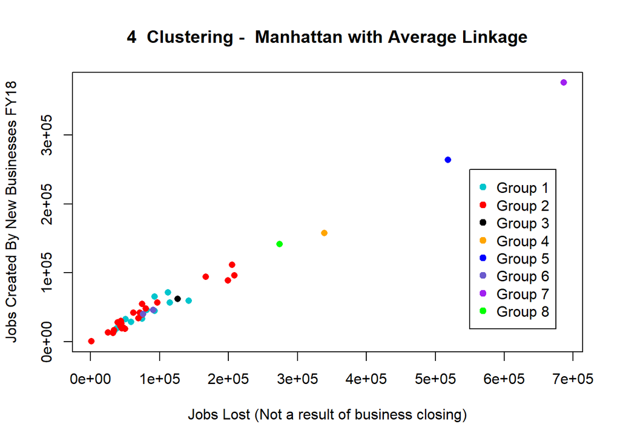

```r
#plotting clusters
colused = c("turquoise3", "red", "black", "orange","blue", "slateblue",  "purple","green", "violetred" )
nclust= 4#change this number for the number of clusters (need 4 because of that first two outlier clusters)
memEucCom = cutree(hc.complete, h=30)#cuts the dendrogram

#job_destruction_continuers and job_creation_births
plot(clean_city$job_destruction_continuers, clean_city$job_creation_births ,pch=16,main=paste(nclust," Clustering -  Manhattan with Average Linkage"), ylab = "Jobs Created By New Businesses FY18", xlab = "Jobs Lost (Not a result of business closing)")
for (i in 1:10)  points(clean_city$job_destruction_continuers[memEucCom == i],clean_city$job_creation_births[memEucCom == i],pch=16,col=colused[i])
legend(550000, 250000, legend=c("Group 1", "Group 2", "Group 3", "Group 4", "Group 5", "Group 6", "Group 7", "Group 8"), col=c("turquoise3", "red", "black", "orange","blue", "slateblue",  "purple","green", "violetred"), pch = 19)
```

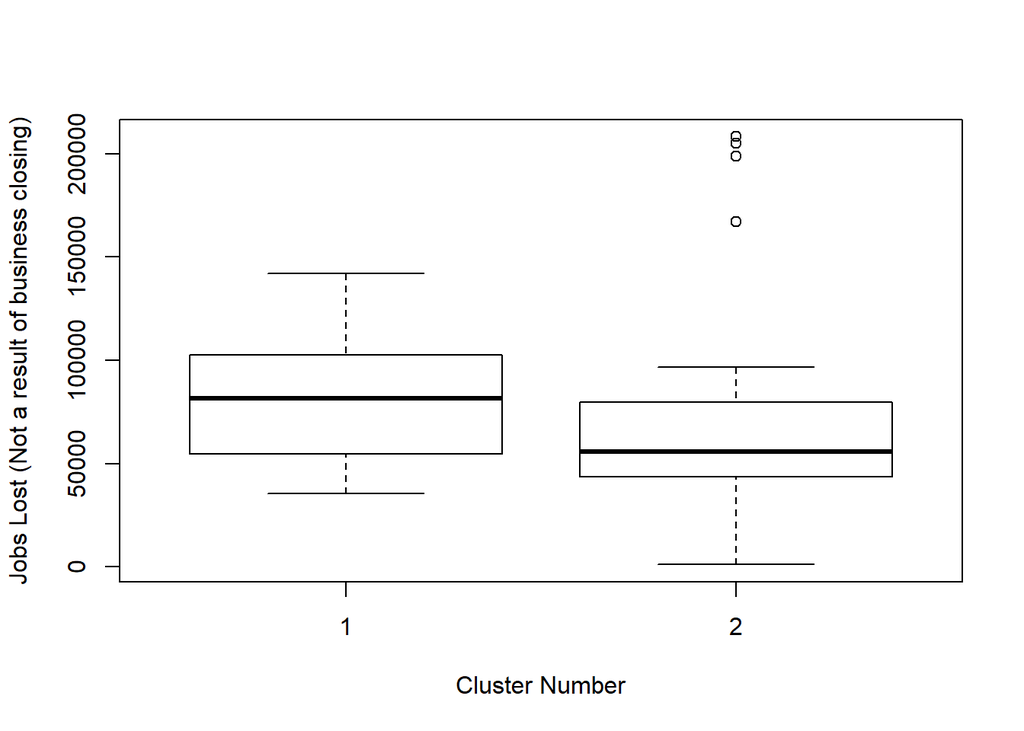

```r
boxplot(job_destruction_continuers[memEucCom<3] ~ memEucCom[memEucCom<3], data = xsubset, xlab = "Cluster Number", ylab = "Jobs Lost (Not a result of business closing)")
```

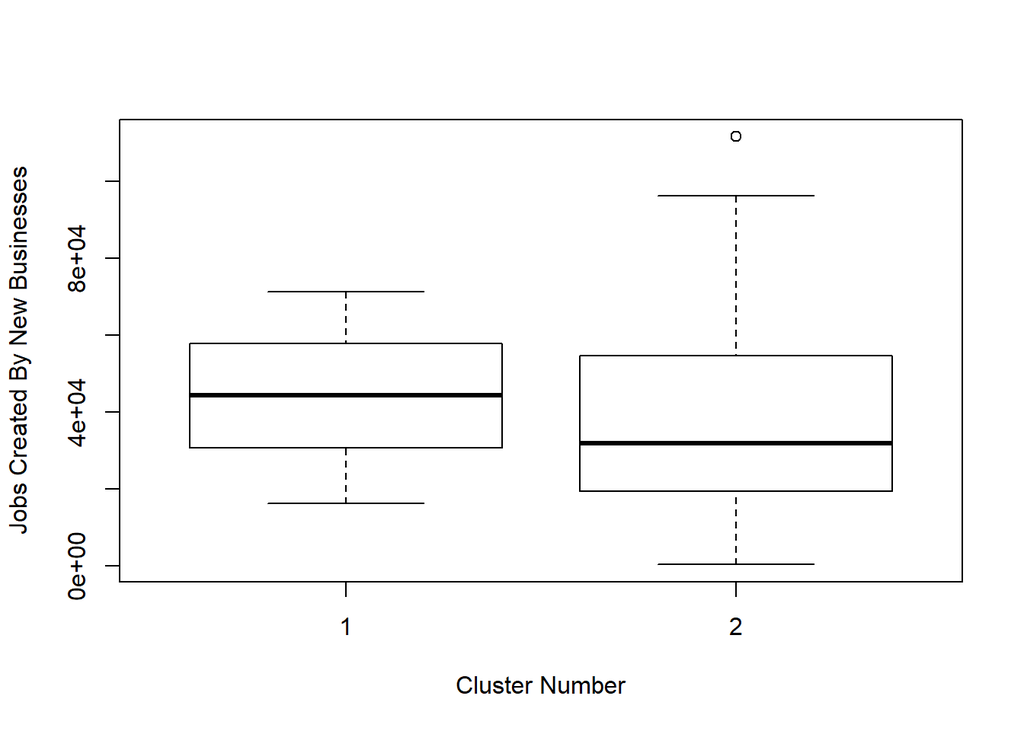

```r
boxplot(job_creation_births[memEucCom<3] ~ memEucCom[memEucCom<3], data = xsubset, xlab = "Cluster Number", ylab = "Jobs Created By New Businesses")
```

```r
median(xsubset$job_destruction_continuers[memEucCom=1])
```

```
## [1] 74877
```

```r
median(xsubset$job_destruction_continuers[memEucCom=2])
```

```
## [1] 47221
```

```r
median(xsubset$job_creation_births[memEucCom=1])
```

```
## [1] 33593
```

```r
median(xsubset$job_creation_births[memEucCom=2])
```

```
## [1] 20352
```

####K-means Non-hierarchical Clustierting

[figure not shown]

```
## [1] 91761.5
```

```
## [1] 61728
```

```
## [1] 45936.5
```

```
## [1] 34104
```

```r
set.seed(2071, sample.kind = "Rounding")
```

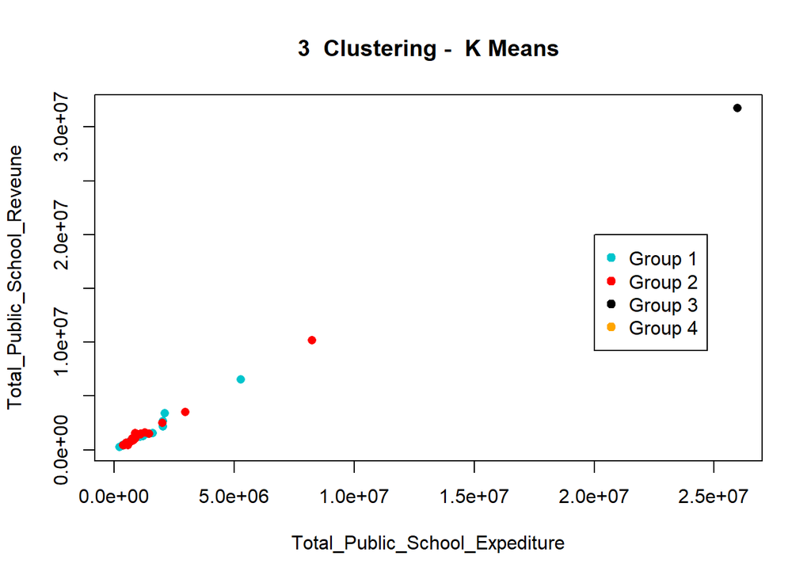

```r
#Total_Public_School_Expediture and Total_Public_School_Reveune
plot(clean_city$Total_Public_School_Expediture, clean_city$Total_Public_School_Reveune, pch=16, main=paste(nclust," Clustering -  K Means"), ylab = "Total_Public_School_Reveune", xlab = "Total_Public_School_Expediture")
for (i in 1:9)  points(clean_city$Total_Public_School_Expediture[membkmean == i],clean_city$Total_Public_School_Reveune[membkmean == i],pch=16,col=colused[i])
legend(20000000, 20000000, legend=c("Group 1", "Group 2", "Group 3", "Group 4"), col=c("turquoise3", "red", "black", "orange"), pch = 19)
```

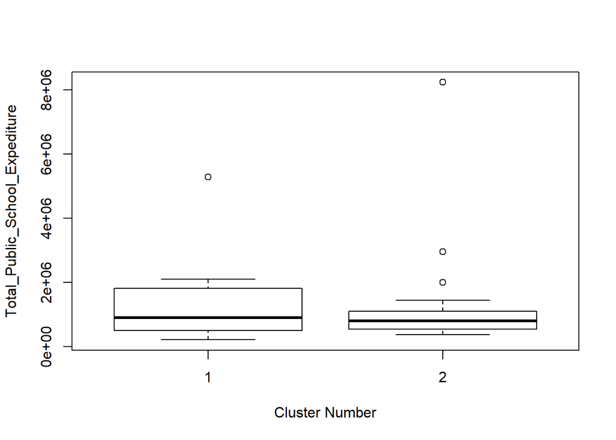

```r
boxplot(Total_Public_School_Expediture[membkmean<3] ~ membkmean[membkmean<3], data = xsubset, xlab = "Cluster Number", ylab = "Total_Public_School_Expediture")
```

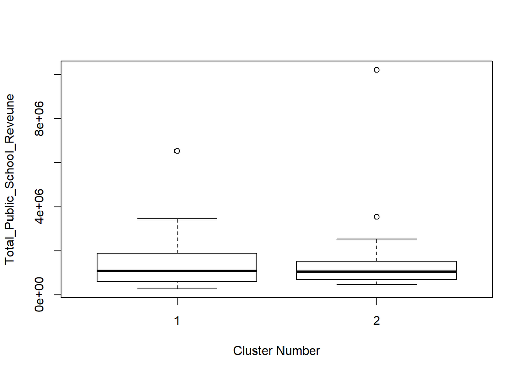

```r
boxplot(Total_Public_School_Reveune[membkmean<3] ~ membkmean[membkmean<3], data = xsubset, xlab = "Cluster Number", ylab = "Total_Public_School_Reveune")
```

```r
median(xsubset$Total_Public_School_Expediture[membkmean==1])
```

```
## [1] 895655
```

```r
median(xsubset$Total_Public_School_Expediture[membkmean==2])
```

```
## [1] 800625
```

```r
median(xsubset$Total_Public_School_Reveune[membkmean==1])
```

```
## [1] 1068180
```

```r
median(xsubset$Total_Public_School_Reveune[membkmean==2])
```

```
## [1] 1037204
```

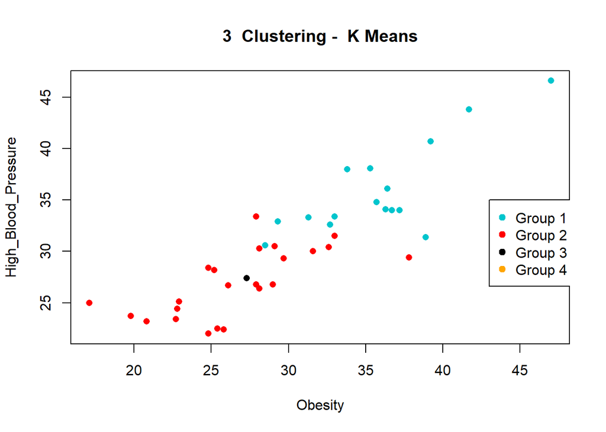

```r
#Obesity and High Blood Pressure
plot(clean_city$Obesity, clean_city$High_Blood_Pressure, pch=16, main=paste(nclust," Clustering -  K Means"), ylab = "High_Blood_Pressure", xlab = "Obesity")
for (i in 1:9)  points(clean_city$Obesity[membkmean == i],clean_city$High_Blood_Pressure[membkmean == i],pch=16,col=colused[i])
legend(43, 35, legend=c("Group 1", "Group 2", "Group 3", "Group 4"), col=c("turquoise3", "red", "black", "orange"), pch = 19)
```

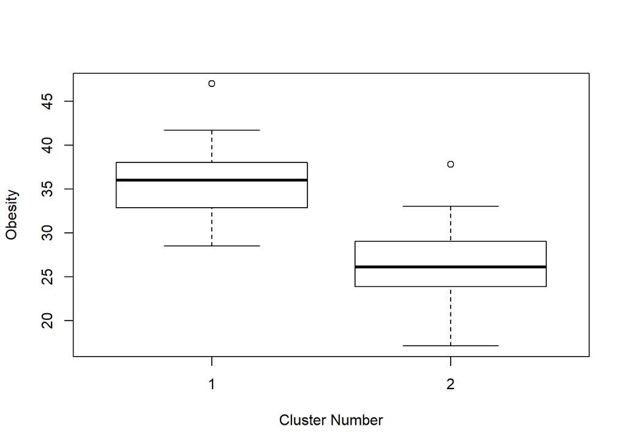

```r
boxplot(Obesity[membkmean<3] ~ membkmean[membkmean<3], data = xsubset, xlab = "Cluster Number", ylab = "Obesity")
```

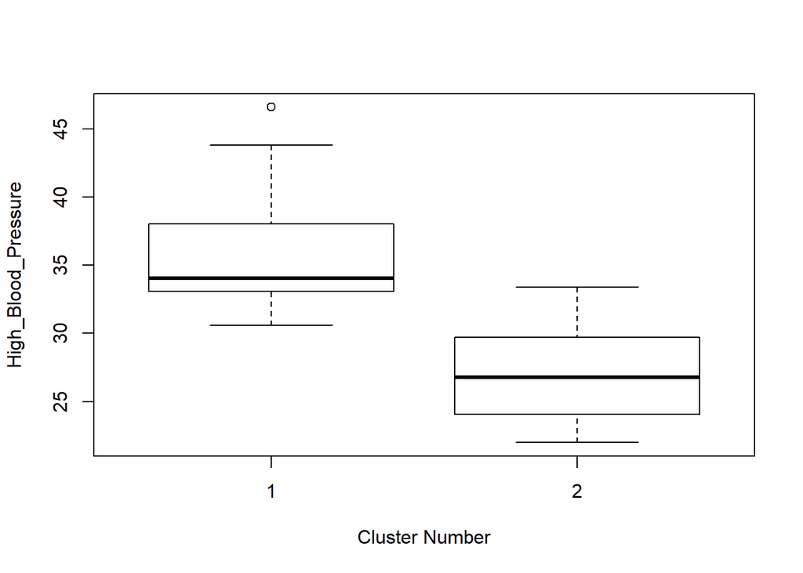

```r
boxplot(High_Blood_Pressure[membkmean<3] ~ membkmean[membkmean<3], data = xsubset, xlab = "Cluster Number", ylab = "High_Blood_Pressure")
```

```r
median(xsubset$Obesity[membkmean==1])
```

```
## [1] 36
```

```r
median(xsubset$Obesity[membkmean==2])
```

```
## [1] 26.1
```

```r
median(xsubset$High_Blood_Pressure[membkmean==1])
```

```
## [1] 34.05
```

```r
median(xsubset$High_Blood_Pressure[membkmean==2])
```

```
## [1] 26.8
```

Truth Table from K Means - With Seed 2071 I: Cluster 2 (total of 23 data points) Had 16 I’s and 7 S’s S: Cluster 1 (total of 16 points) Had 12 S’s and 4 I’s

##Association Rules Now that we have accepted K Means has the best clustering model, we can select the rows in our original dataset that are a part of group 1 and group 2 which were correct and build association rules for those cities We will include all avaiable features in our dataset for the association analysis that were Identified as important variables by PCA.

###Integrated Cities

```r
#read in dataset
KM_Int = read.csv("KMeans Int Correct.csv")
#remove label and ID columns
KM_Int <- KM_Int[, c(-1,-2,-4,-5)]
```

Make all variables Discrete Ranges for the analysis

```r
KM_Int$Estimated_City_Total_Population = discretize(KM_Int$Estimated_City_Total_Population, "fixed", breaks=c(min(KM_Int$Estimated_City_Total_Population), quantile(KM_Int$Estimated_City_Total_Population, 0.25), quantile(KM_Int$Estimated_City_Total_Population, 0.75), max(KM_Int$Estimated_City_Total_Population)), ordered=T)
KM_Int$Estimated_City_Population_5.17 = discretize(KM_Int$Estimated_City_Population_5-17, "fixed", breaks=c(min(KM_Int$Estimated_City_Population_5-17), quantile(KM_Int$Estimated_City_Population_5-17, 0.25), quantile(KM_Int$Estimated_City_Population_5-17, 0.75), max(KM_Int$Estimated_City_Population_5-17)), ordered=T)
KM_Int$SNAP_Recipients_July_17 = discretize(KM_Int$SNAP_Recipients_July_17, "fixed", breaks=c(min(KM_Int$SNAP_Recipients_July_17), quantile(KM_Int$SNAP_Recipients_July_17, 0.25), quantile(KM_Int$SNAP_Recipients_July_17, 0.75), max(KM_Int$SNAP_Recipients_July_17)), ordered=T)
KM_Int$Total_Public_School_Expediture = discretize(KM_Int$Total_Public_School_Expediture, "fixed", breaks=c(min(KM_Int$Total_Public_School_Expediture), quantile(KM_Int$Total_Public_School_Expediture, 0.25), quantile(KM_Int$Total_Public_School_Expediture, 0.75), max(KM_Int$Total_Public_School_Expediture)), ordered=T)
KM_Int$Prct_of_US_Total_School_Expenditure_ = discretize(KM_Int$Prct_of_US_Total_School_Expenditure_, "fixed", breaks=c(min(KM_Int$Prct_of_US_Total_School_Expenditure_), quantile(KM_Int$Prct_of_US_Total_School_Expenditure_, 0.25), quantile(KM_Int$Prct_of_US_Total_School_Expenditure_, 0.75), max(KM_Int$Prct_of_US_Total_School_Expenditure_)), ordered=T)
KM_Int$Public_School_Teacher_Salary_Expenses = discretize(KM_Int$Public_School_Teacher_Salary_Expenses, "fixed", breaks=c(min(KM_Int$Public_School_Teacher_Salary_Expenses), quantile(KM_Int$Public_School_Teacher_Salary_Expenses, 0.25), quantile(KM_Int$Public_School_Teacher_Salary_Expenses, 0.75), max(KM_Int$Public_School_Teacher_Salary_Expenses)), ordered=T)
KM_Int$Total_Public_School_Reveune = discretize(KM_Int$Total_Public_School_Reveune, "fixed", breaks=c(min(KM_Int$Total_Public_School_Reveune), quantile(KM_Int$Total_Public_School_Reveune, 0.25), quantile(KM_Int$Total_Public_School_Reveune, 0.75), max(KM_Int$Total_Public_School_Reveune)), ordered=T)
KM_Int$State_Public_School_Revenue = discretize(KM_Int$State_Public_School_Revenue, "fixed", breaks=c(min(KM_Int$State_Public_School_Revenue), quantile(KM_Int$State_Public_School_Revenue, 0.25), quantile(KM_Int$State_Public_School_Revenue, 0.75), max(KM_Int$State_Public_School_Revenue)), ordered=T)
KM_Int$Local_Public_School_Revenue = discretize(KM_Int$Local_Public_School_Revenue, "fixed", breaks=c(min(KM_Int$Local_Public_School_Revenue), quantile(KM_Int$Local_Public_School_Revenue, 0.25), quantile(KM_Int$Local_Public_School_Revenue, 0.75), max(KM_Int$Local_Public_School_Revenue)), ordered=T)
KM_Int$estabs = discretize(KM_Int$estabs, "fixed", breaks=c(min(KM_Int$estabs), quantile(KM_Int$estabs, 0.25), quantile(KM_Int$estabs, 0.75), max(KM_Int$estabs)), ordered=T)
KM_Int$estabs_entry = discretize(KM_Int$estabs_entry, "fixed", breaks=c(min(KM_Int$estabs_entry), quantile(KM_Int$estabs_entry, 0.25), quantile(KM_Int$estabs_entry, 0.75), max(KM_Int$estabs_entry)), ordered=T)
KM_Int$estabs_exit = discretize(KM_Int$estabs_exit, "fixed", breaks=c(min(KM_Int$estabs_exit), quantile(KM_Int$estabs_exit, 0.25), quantile(KM_Int$estabs_exit, 0.75), max(KM_Int$estabs_exit)), ordered=T)
KM_Int$job_creation = discretize(KM_Int$job_creation, "fixed", breaks=c(min(KM_Int$job_creation), quantile(KM_Int$job_creation, 0.25), quantile(KM_Int$job_creation, 0.75), max(KM_Int$job_creation)), ordered=T)
KM_Int$job_creation_births = discretize(KM_Int$job_creation_births, "fixed", breaks=c(min(KM_Int$job_creation_births), quantile(KM_Int$job_creation_births, 0.25), quantile(KM_Int$job_creation_births, 0.75), max(KM_Int$job_creation_births)), ordered=T)
KM_Int$job_creation_continuers = discretize(KM_Int$job_creation_continuers, "fixed", breaks=c(min(KM_Int$job_creation_continuers), quantile(KM_Int$job_creation_continuers, 0.25), quantile(KM_Int$job_creation_continuers, 0.75), max(KM_Int$job_creation_continuers)), ordered=T)
KM_Int$job_destruction = discretize(KM_Int$job_destruction, "fixed", breaks=c(min(KM_Int$job_destruction), quantile(KM_Int$job_destruction, 0.25), quantile(KM_Int$job_destruction, 0.75), max(KM_Int$job_destruction)), ordered=T)
KM_Int$job_destruction_deaths = discretize(KM_Int$job_destruction_deaths, "fixed", breaks=c(min(KM_Int$job_destruction_deaths), quantile(KM_Int$job_destruction_deaths, 0.25), quantile(KM_Int$job_destruction_deaths, 0.75), max(KM_Int$job_destruction_deaths)), ordered=T)
KM_Int$job_destruction_continuers = discretize(KM_Int$job_destruction_continuers, "fixed", breaks=c(min(KM_Int$job_destruction_continuers), quantile(KM_Int$job_destruction_continuers, 0.25), quantile(KM_Int$job_destruction_continuers, 0.75), max(KM_Int$job_destruction_continuers)), ordered=T)
KM_Int$net_job_creation_rate = discretize(KM_Int$net_job_creation_rate, "fixed", breaks=c(min(KM_Int$net_job_creation_rate), quantile(KM_Int$net_job_creation_rate, 0.25), quantile(KM_Int$net_job_creation_rate, 0.75), max(KM_Int$net_job_creation_rate)), ordered=T)
KM_Int$Fam_Income_50_to_100K = discretize(KM_Int$Fam_Income_50_to_100K, "fixed", breaks=c(min(KM_Int$Fam_Income_50_to_100K), quantile(KM_Int$Fam_Income_50_to_100K, 0.25), quantile(KM_Int$Fam_Income_50_to_100K, 0.75), max(KM_Int$Fam_Income_50_to_100K)), ordered=T)
KM_Int$Fam_Income_Under_25k = discretize(KM_Int$Fam_Income_Under_25k, "fixed", breaks=c(min(KM_Int$Fam_Income_Under_25k), quantile(KM_Int$Fam_Income_Under_25k, 0.25), quantile(KM_Int$Fam_Income_Under_25k, 0.75), max(KM_Int$Fam_Income_Under_25k)), ordered=T)
KM_Int$Homeowners = discretize(KM_Int$Homeowners, "fixed", breaks=c(min(KM_Int$Homeowners), quantile(KM_Int$Homeowners, 0.25), quantile(KM_Int$Homeowners, 0.75), max(KM_Int$Homeowners)), ordered=T)
KM_Int$Renters = discretize(KM_Int$Renters, "fixed", breaks=c(min(KM_Int$Renters), quantile(KM_Int$Renters, 0.25), quantile(KM_Int$Renters, 0.75), max(KM_Int$Renters)), ordered=T)
KM_Int$Welfare = discretize(KM_Int$Welfare, "fixed", breaks=c(min(KM_Int$Welfare), quantile(KM_Int$Welfare, 0.25), quantile(KM_Int$Welfare, 0.75), max(KM_Int$Welfare)), ordered=T)
KM_Int$Heart_Disease_Age_35_to_64 = discretize(KM_Int$Heart_Disease_Age_35_to_64, "fixed", breaks=c(min(KM_Int$Heart_Disease_Age_35_to_64), quantile(KM_Int$Heart_Disease_Age_35_to_64, 0.25), quantile(KM_Int$Heart_Disease_Age_35_to_64, 0.75), max(KM_Int$Heart_Disease_Age_35_to_64)), ordered=T)
KM_Int$Heart_Disease_Age_65_Up = discretize(KM_Int$Heart_Disease_Age_65_Up, "fixed", breaks=c(min(KM_Int$Heart_Disease_Age_65_Up), quantile(KM_Int$Heart_Disease_Age_65_Up, 0.25), quantile(KM_Int$Heart_Disease_Age_65_Up, 0.75), max(KM_Int$Heart_Disease_Age_65_Up)), ordered=T)
KM_Int$Stroke_Age_35_to_64 = discretize(KM_Int$Stroke_Age_35_to_64, "fixed", breaks=c(min(KM_Int$Stroke_Age_35_to_64), quantile(KM_Int$Stroke_Age_35_to_64, 0.25), quantile(KM_Int$Stroke_Age_35_to_64, 0.75), max(KM_Int$Stroke_Age_35_to_64)), ordered=T)
KM_Int$High_Blood_Pressure = discretize(KM_Int$High_Blood_Pressure, "fixed", breaks=c(min(KM_Int$High_Blood_Pressure), quantile(KM_Int$High_Blood_Pressure, 0.25), quantile(KM_Int$High_Blood_Pressure, 0.75), max(KM_Int$High_Blood_Pressure)), ordered=T)
KM_Int$COPD = discretize(KM_Int$COPD, "fixed", breaks=c(min(KM_Int$COPD), quantile(KM_Int$COPD, 0.25), quantile(KM_Int$COPD, 0.75), max(KM_Int$COPD)), ordered=T)
KM_Int$Smokers = discretize(KM_Int$Smokers, "fixed", breaks=c(min(KM_Int$Smokers), quantile(KM_Int$Smokers, 0.25), quantile(KM_Int$Smokers, 0.75), max(KM_Int$Smokers)), ordered=T)
KM_Int$Regular_Dental_Cleanings = discretize(KM_Int$Regular_Dental_Cleanings, "fixed", breaks=c(min(KM_Int$Regular_Dental_Cleanings), quantile(KM_Int$Regular_Dental_Cleanings, 0.25), quantile(KM_Int$Regular_Dental_Cleanings, 0.75), max(KM_Int$Regular_Dental_Cleanings)), ordered=T)
KM_Int$Diabetes = discretize(KM_Int$Diabetes, "fixed", breaks=c(min(KM_Int$Diabetes), quantile(KM_Int$Diabetes, 0.25), quantile(KM_Int$Diabetes, 0.75), max(KM_Int$Diabetes)), ordered=T)
KM_Int$Leisure_Time_Exercise = discretize(KM_Int$Leisure_Time_Exercise, "fixed", breaks=c(min(KM_Int$Leisure_Time_Exercise), quantile(KM_Int$Leisure_Time_Exercise, 0.25), quantile(KM_Int$Leisure_Time_Exercise, 0.75), max(KM_Int$Leisure_Time_Exercise)), ordered=T)
KM_Int$Poor_Mental_Health = discretize(KM_Int$Poor_Mental_Health, "fixed", breaks=c(min(KM_Int$Poor_Mental_Health), quantile(KM_Int$Poor_Mental_Health, 0.25), quantile(KM_Int$Poor_Mental_Health, 0.75), max(KM_Int$Poor_Mental_Health)), ordered=T)
KM_Int$Obesity = discretize(KM_Int$Obesity, "fixed", breaks=c(min(KM_Int$Obesity), quantile(KM_Int$Obesity, 0.25), quantile(KM_Int$Obesity, 0.75), max(KM_Int$Obesity)), ordered=T)
KM_Int$Poor_Physical_Health = discretize(KM_Int$Poor_Physical_Health, "fixed", breaks=c(min(KM_Int$Poor_Physical_Health), quantile(KM_Int$Poor_Physical_Health, 0.25), quantile(KM_Int$Poor_Physical_Health, 0.75), max(KM_Int$Poor_Physical_Health)), ordered=T)
KM_Int$Lack_of_Sleep = discretize(KM_Int$Lack_of_Sleep, "fixed", breaks=c(min(KM_Int$Lack_of_Sleep), quantile(KM_Int$Lack_of_Sleep, 0.25), quantile(KM_Int$Lack_of_Sleep, 0.75), max(KM_Int$Lack_of_Sleep)), ordered=T)
```

```r
rules = apriori(KM_Int, parameter = list(support = 0.2, confidence = 0.8))
```

```
## Apriori
##
## Parameter specification:
##  confidence minval smax arem  aval originalSupport maxtime support minlen
##         0.8    0.1    1 none FALSE            TRUE       5     0.2      1
##  maxlen target   ext
##      10  rules FALSE
##
## Algorithmic control:
##  filter tree heap memopt load sort verbose
##     0.1 TRUE TRUE  FALSE TRUE    2    TRUE
##
## Absolute minimum support count: 5
##
## set item appearances ...[0 item(s)] done [0.00s].
## set transactions ...[113 item(s), 28 transaction(s)] done [0.00s].
## sorting and recoding items ... [112 item(s)] done [0.00s].
## creating transaction tree ... done [0.00s].
## checking subsets of size 1 2 3 4 5 6 7 8 9 10
```

```
##  done [0.00s].
## writing ... [34477 rule(s)] done [0.00s].
## creating S4 object  ... done [0.01s].
```

```r
summary(rules)
```

```
## set of 34477 rules
##
## rule length distribution (lhs + rhs):sizes
##    2    3    4    5    6    7    8    9   10
##  402 3183 7121 8726 7637 4811 2035  507   55
##
##    Min. 1st Qu.  Median    Mean 3rd Qu.    Max.
##   2.000   4.000   5.000   5.318   6.000  10.000
##
## summary of quality measures:
##     support         confidence         lift           count
##  Min.   :0.2143   Min.   :0.800   Min.   :1.400   Min.   : 6.000
##  1st Qu.:0.2143   1st Qu.:1.000   1st Qu.:2.000   1st Qu.: 6.000
##  Median :0.2143   Median :1.000   Median :2.000   Median : 6.000
##  Mean   :0.2380   Mean   :0.972   Mean   :2.176   Mean   : 6.663
##  3rd Qu.:0.2500   3rd Qu.:1.000   3rd Qu.:2.000   3rd Qu.: 7.000
##  Max.   :0.5000   Max.   :1.000   Max.   :4.000   Max.   :14.000
##
## mining info:
##    data ntransactions support confidence
##  KM_Int            28     0.2        0.8
```

```r
nonRedunt= which(interestMeasure(rules, measure = "improvement", quality_measure = "confidence") >= 0)
#pick out rules that are not redunuant (only pick rules that are an improvemnet with the same consquent)

summary(rules[nonRedunt])
```

```
## set of 30746 rules
##
## rule length distribution (lhs + rhs):sizes
##    2    3    4    5    6    7    8    9   10
##  402 2693 5835 7692 7088 4562 1940  482   52
##
##    Min. 1st Qu.  Median    Mean 3rd Qu.    Max.
##   2.000   4.000   5.000   5.384   6.000  10.000
##
## summary of quality measures:
##     support         confidence          lift           count
##  Min.   :0.2143   Min.   :0.8000   Min.   :1.400   Min.   : 6.000
##  1st Qu.:0.2143   1st Qu.:1.0000   1st Qu.:2.000   1st Qu.: 6.000
##  Median :0.2143   Median :1.0000   Median :2.000   Median : 6.000
##  Mean   :0.2362   Mean   :0.9848   Mean   :2.231   Mean   : 6.614
##  3rd Qu.:0.2500   3rd Qu.:1.0000   3rd Qu.:2.000   3rd Qu.: 7.000
##  Max.   :0.5000   Max.   :1.0000   Max.   :4.000   Max.   :14.000
##
## mining info:
##    data ntransactions support confidence
##  KM_Int            28     0.2        0.8
```

```r
rulesClean = rules[nonRedunt]
```

Taking a look at the top 10 rules, in descending order of lift provided:

```r
highLift = subset(rulesClean, subset = lift > 1 & confidence > 0.65)
subRules = head(highLift, n = 10, by = "lift")
inspect(subRules)
```

```
##      lhs                                                 rhs                                              support confidence lift count
## [1]  {Renters=[0.192,0.37)}                           => {Homeowners=[0.63,0.808]}                           0.25          1    4     7
## [2]  {Homeowners=[0.63,0.808]}                        => {Renters=[0.192,0.37)}                              0.25          1    4     7
## [3]  {Renters=[0.446,0.67]}                           => {Homeowners=[0.33,0.554)}                           0.25          1    4     7
## [4]  {Homeowners=[0.33,0.554)}                        => {Renters=[0.446,0.67]}                              0.25          1    4     7
## [5]  {job_destruction_continuers=[9.27e+04,6.86e+05]} => {job_destruction_deaths=[4.74e+04,3.7e+05]}         0.25          1    4     7
## [6]  {job_destruction_deaths=[4.74e+04,3.7e+05]}      => {job_destruction_continuers=[9.27e+04,6.86e+05]}    0.25          1    4     7
## [7]  {job_destruction_continuers=[9.27e+04,6.86e+05]} => {job_destruction=[1.35e+05,1.06e+06]}               0.25          1    4     7
## [8]  {job_destruction=[1.35e+05,1.06e+06]}            => {job_destruction_continuers=[9.27e+04,6.86e+05]}    0.25          1    4     7
## [9]  {job_destruction_continuers=[9.27e+04,6.86e+05]} => {job_creation_continuers=[1.12e+05,8.1e+05]}        0.25          1    4     7
## [10] {job_creation_continuers=[1.12e+05,8.1e+05]}     => {job_destruction_continuers=[9.27e+04,6.86e+05]}    0.25          1    4     7
```

```r
#right hand Side I
highLift = subset(rulesClean, subset = lift > 1 & confidence > 0.60)
myrhs = rhs(rulesClean)
iors = which(myrhs %in% c("Status=I"))
#inspect(head(rulesClean[ iors ], n=100, by="lift" ))
```

```r
#right hand Side S
highLift = subset(rulesClean, subset = lift > 1 & confidence > 0.60)
myrhs = rhs(rulesClean)
iors = which(myrhs %in% c("Status=S"))
#inspect(head(rulesClean[ iors ], n=100, by="lift" ))
```